# Variance and the Central Limit Theorem

Variance is a magical quantity that is hugely important for the Central Limit Theorem.

### Simulation

What happens when we take an average of lots of random variables? Let’s do an experiment.

Imagine sampling 100 Bernoulli(.6) random variables, then taking their average. That is a new random variable. What does it behave like?  
Here is a histogram of 5000 of those random variables.

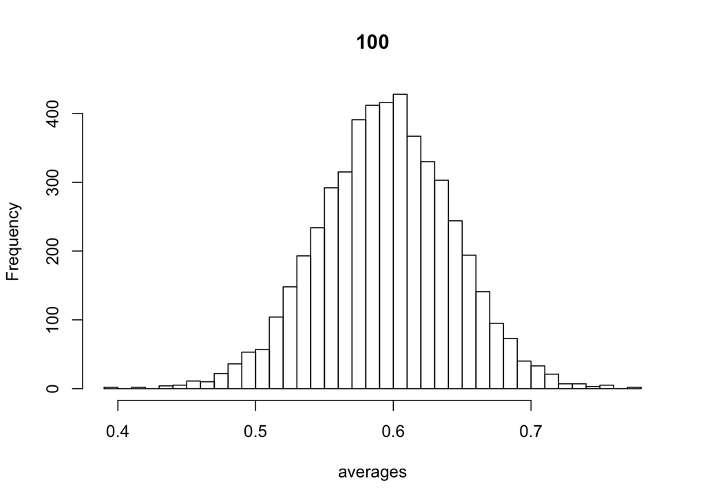

```r
averages = generateLotsOfBernoulliAverages(100, 5000, .6)
hist(averages, breaks= 40, main = 100)
```

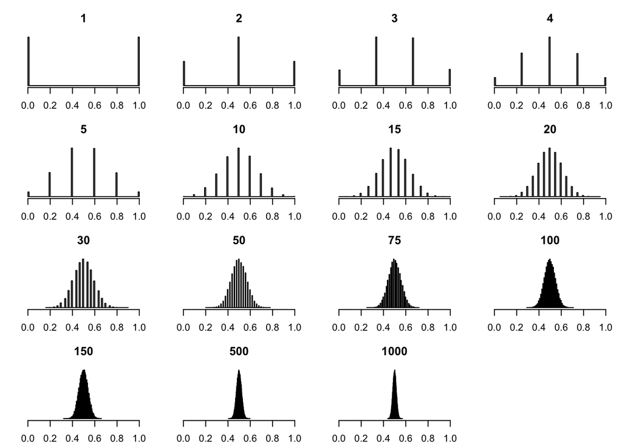

These two things above happen whenever you take averages of random variables that are independent and identically distributed. There are some [strange distributions](https://en.wikipedia.org/wiki/St._Petersburg_paradox) that are [exceptions to this rule](https://en.wikipedia.org/wiki/Cauchy_distribution); but we will not encounter them in this course and they come up infrequently in applications.

For example, here is the Geometric(p = .1) distribution. It is how many flips it takes to get your first heads.

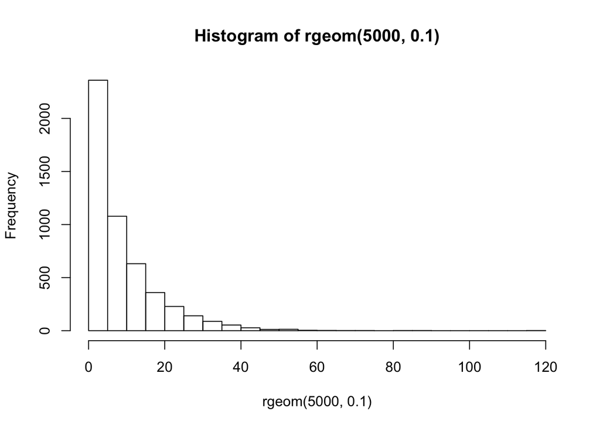

```r
hist(rgeom(5000, .1), breaks = 20)
```

Notice how it is “skewed” to the right.

Imagine sampling 100 Geometric(.1) random variables, then taking their average. Here is a histogram of 5000 such random variables

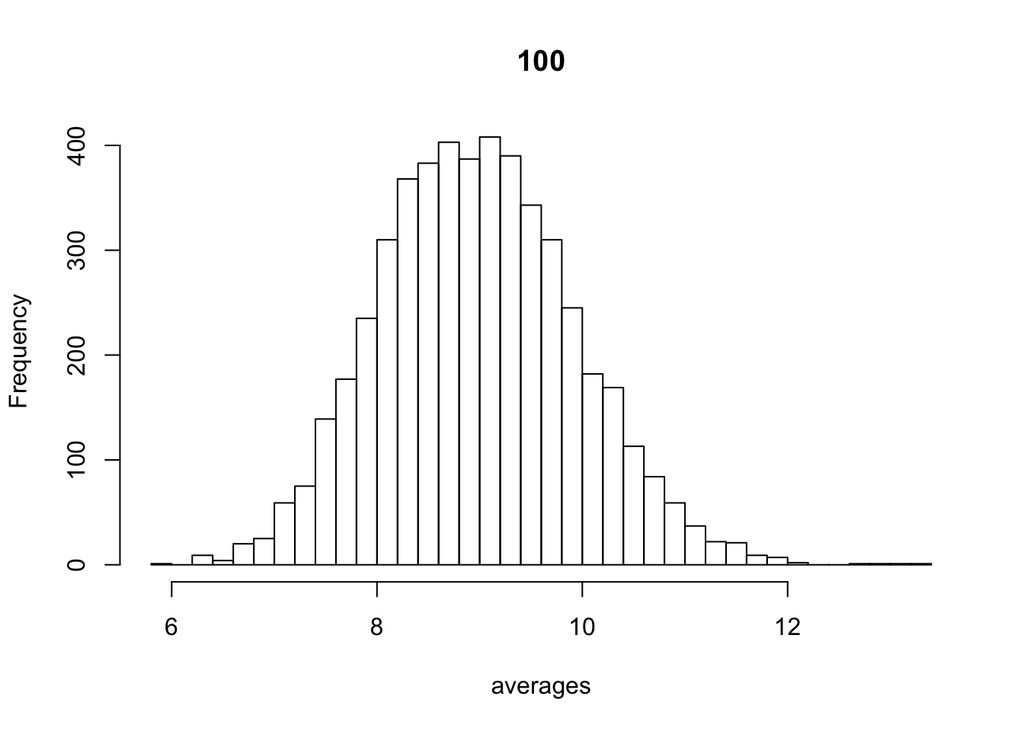

```r
averages = generateLotsOfAverages(rgeom, 100, 5000, prob = .1)
hist(averages, breaks= 40, main = 100)
```

Here is that histogram for a sequence n = 1,2,3,4,5,10,15,20,30,50,75,100,150, 500,1000.

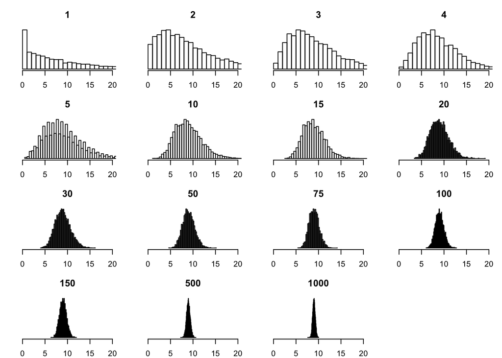

We see the same phenomenon with these averages as we did with the Bernoulli averges. As n gets bigger, the averages are all clumping around a certain value, but the average is still random, and the shape of its distribution looks more and more like a Gaussian.

### See board for lecture notes on Variance and Standard Deviation

How do the above histograms look when we center (by the expectation) and scale (by the standard error)?

Here are histograms for centered and scaled averages of Bernoulli random variables:

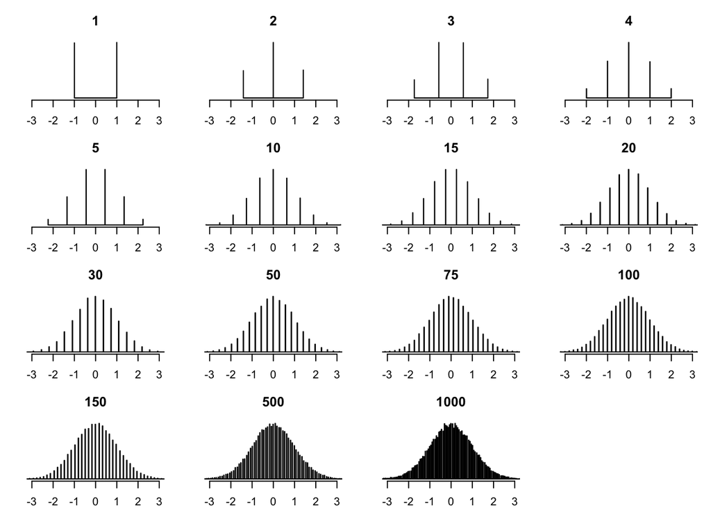

Here are histograms for centered and scaled averages of Geometric random variables:

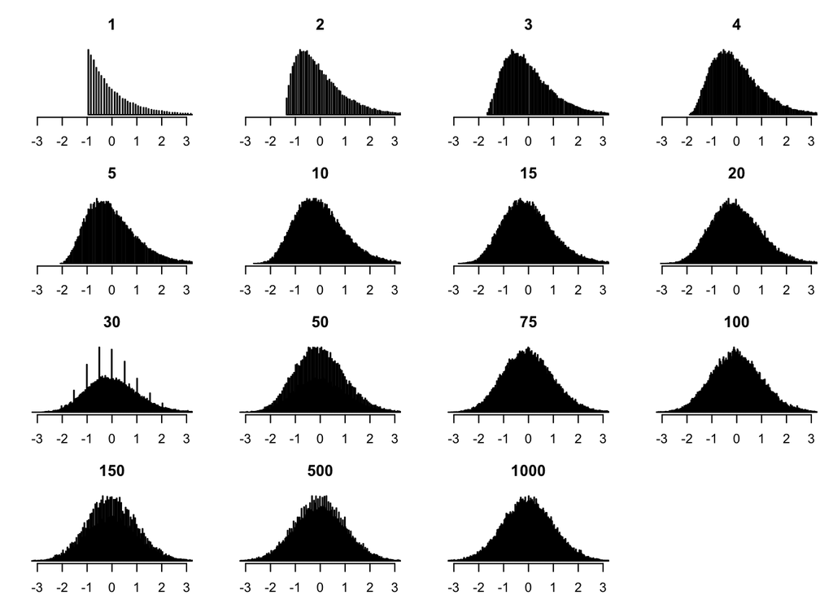

### The CLT is like computer-free Monte Carlo that works for a small subset of problems.

If $\bar X$ is the averge of many independent random variables and $Z \sim N(0,1)$ is a standard normal random variable. The CLT enables us to approximate/compute the same types of probabilities that we used Monte Carlo for. First, notice that
$$P(\bar X > a)=
P(\bar X - E(\bar X) > a - E(\bar X))
= P\left(\frac{\bar X - E(\bar X)}{SE(\bar X)} > \frac{a - E(\bar X)}{SE(\bar X)}\right).$$
Thus, we can approximate $P(\bar X > a)$ as follows:
$$P(\bar X > a) =
P\left(\frac{\bar X - E(\bar X)}{SE(\bar X)} > \frac{a - E(\bar X)}{SE(\bar X)}\right) \approx P\left(Z > \frac{a - E(\bar X)}{SE(\bar X)}\right).$$
With Monte Carlo, you could approximate/compute the left hand side by simulating $\bar X$ a million times and then seeing what proportion of those times $\bar X > a$. Alternatively, you could use the right hand side and look it up in a Z-table (or use pnorm).